# Statistical Inference Project Part 2: Basic Inferential Data Analysis

Gabriel Quinmat

6 de mayo de 2018

## Overview

Now in the second portion of the project, we’re going to analyze the ToothGrowth data in the R datasets package.

Load the ToothGrowth data and perform some basic exploratory data analyses Provide a basic summary of the data. Use confidence intervals and/or hypothesis tests to compare tooth growth by supp and dose. (Only use the techniques from class, even if there’s other approaches worth considering) State your conclusions and the assumptions needed for your conclusions.

## Loading and Analysis

We are going to work with ToothGrow dataset. The Effect of Vitamin C on Tooth Growth in Guinea Pigs.

```r
library("datasets")
data("ToothGrowth")
summary(ToothGrowth)
```

```
##       len        supp         dose
##  Min.   : 4.20   OJ:30   Min.   :0.500
##  1st Qu.:13.07   VC:30   1st Qu.:0.500
##  Median :19.25           Median :1.000
##  Mean   :18.81           Mean   :1.167
##  3rd Qu.:25.27           3rd Qu.:2.000
##  Max.   :33.90           Max.   :2.000
```

Looking the data we know now that we have 60 observations, in which 30 correspond to guinea pigs that were given vitamin c and the others Orange Juice. We can separate them in differents datasets to analyze them.

```r
ojT <- ToothGrowth %>% filter(supp == "OJ") %>% select(len, dose)
vcT <- ToothGrowth %>% filter(supp == "VC") %>% select(len, dose)
```

A quick summary of both datasets:

For supp OJ:

```r
summary(ojT)
```

```
##       len             dose
##  Min.   : 8.20   Min.   :0.500
##  1st Qu.:15.53   1st Qu.:0.500
##  Median :22.70   Median :1.000
##  Mean   :20.66   Mean   :1.167
##  3rd Qu.:25.73   3rd Qu.:2.000
##  Max.   :30.90   Max.   :2.000
```

For supp VC:

```r
summary(vcT)
```

```
##       len             dose
##  Min.   : 4.20   Min.   :0.500
##  1st Qu.:11.20   1st Qu.:0.500
##  Median :16.50   Median :1.000
##  Mean   :16.96   Mean   :1.167
##  3rd Qu.:23.10   3rd Qu.:2.000
##  Max.   :33.90   Max.   :2.000
```

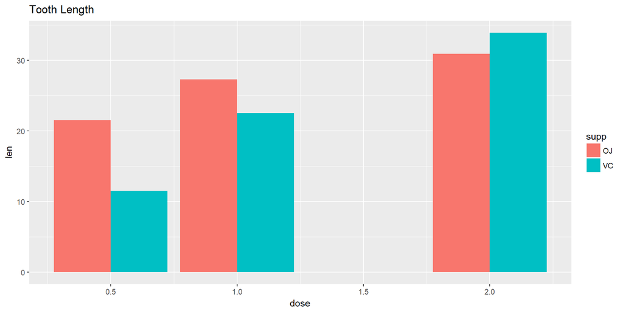

```r
ToothGrowth %>% ggplot(aes(x = dose, y = len, fill = supp)) +
      geom_bar(position = "dodge", stat = "identity") +
      labs(title = "Tooth Length ")
```

So we can see how tooth length is increasing as supplement dose increases. At first, vitamin C is not effecttive as orange juice, but with 2 mm/day is greater.

```r
muOj <- mean(ojT$len)
muVc <- mean(vcT$len)

varOj <- var(ojT$len)
varVc <- var(vcT$len)

sdOj <- sd(ojT$len)
sdVc <- sd(vcT$len)
```

Orange Juice Length Mean: 20.6633333

Orange Juice Length Variance: 43.6334368

Orange Juice Length Standard Deviation: 6.605561

Vitamin C Length Mean: 16.9633333

Vitamin C Length Variance: 68.3272299

Vitamin C Length Standard Deviation: 8.2660287

## Hypothesis Test & Confidence Intervals

Gosset’s distribution will be a good distribution for testing as the dataset is not large.

For making t test, we need to get the difference between both supplements. Let’s make a hypothesis

H0 <- muOj - muVc = 0 Ha <- muOj - muVc != 0

### Length tooth test

```r
test <- t.test(ojT$len, vcT$len, paired = TRUE)
```

Now he know the confidence interval: 1.4086586, 5.9913414

Interval does not cross zero.

And a P-Value: 0.0025498

And P-Value is close to 0.

Thus, we can see that there is a difference between supplement and we can reject the null hypothesis.

### Dose and Length test

We will select only 1.0 and 2.0 doses.

```r
toothDose <- ToothGrowth %>% filter(dose == 1.0 | dose == 2.0)
test2 <- t.test(len~dose, paired = TRUE, data = toothDose)
```

Confidence interval: -9.2581857, -3.4718143

And P-Value: 1.93418610^{-4}

Again, but more significantly, we have a confidence interval that does not across zero and a p-value close to zero. so we can reject the null hypothesis.